# The Persistence of the Analytic School... Until the Continental

By: Kaitlyn Brown

Many schools of philsophy have come and gone since the field's beginning with the likes of Plato and Aristotle. It is to be expected that these schools, often created with the purpose of opposing of each other, are vastly different. What I consider to be more interesting and less obvious is whether these schools of philosophy experience changes and development within themselves, and to what extent? To begin to answer this question, I determined which school of philosophy dominated, or was most prolific, over history. To make this determination, I ranked the schools by number of total sentences written within each year for which there is available data, and chose the top school.

```python
import pandas as pd
import matplotlib.pyplot as plt

df = pd.read_csv('philosophy_data.csv')

years = df['original_publication_date'].unique()
year_top_school_map  = {}
for y in years:
    current_year = df[df['original_publication_date'] == y]
    top_school = current_year.groupby('school').count()['sentence_spacy'].sort_values(ascending = False).head(1).index[0]
    year_top_school_map[y] = top_school

year_top_school_map = dict(sorted(year_top_school_map.items()))
```

The results of this analysis are shown here:

```python
year_top_school_map
```

```
{-350: 'plato',
 -320: 'aristotle',
 125: 'stoicism',
 170: 'stoicism',
 1637: 'rationalism',
 1641: 'rationalism',
 1674: 'rationalism',
 1677: 'rationalism',
 1689: 'empiricism',
 1710: 'rationalism',
 1713: 'empiricism',
 1739: 'empiricism',
 1776: 'capitalism',
 1779: 'empiricism',
 1781: 'german_idealism',
```

[output cut: 33 more lines]

One notable finding from this analysis is that unlike most other schools, the analytic school seems to have two phases in which it was predominant: the second decade and sixth decade of the 1900s. To confirm this trend, we can isolate the work of the analytic school and consider how many sentences were written within that school over history.

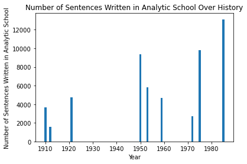

```python
analytic = df[df['school'] == 'analytic']
x = []
y = []
for year in analytic['original_publication_date'].unique():
    x.append(year)
    y.append(analytic[analytic['original_publication_date'] == year].count()['title'])

plt.bar(x, y)
plt.title('Number of Sentences Written in Analytic School Over History')
plt.xlabel('Year')
plt.ylabel('Number of Sentences Written in Analytic School')
```

It is clear that there were two distinct eras of the analytic school, with a gap with no analytic writings between 1920 and 1950. This significant gap might suggest two versions of the analytic school with detectable differences. To determine whether this is the case, we can consider the ideas, form, and emotions of the two eras' texts.

First, we consider the words, ignoring commonly-used words (such as "the and "or"), most frequently used in the texts of the two eras. Below are word clouds displaying the most common words of each era.

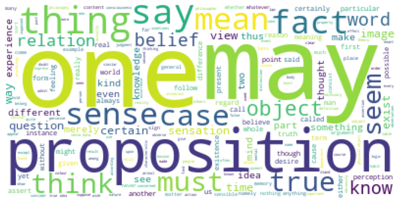

```python
import nltk
from nltk import FreqDist
from nltk.corpus import stopwords
from nltk.probability import FreqDist
from wordcloud import WordCloud
import warnings
warnings.filterwarnings('ignore')

analytic1 = analytic[analytic['original_publication_date'] < 1930]
analytic2 = analytic[analytic['original_publication_date'] > 1930]

nltk.download('stopwords')
stopwords = nltk.corpus.stopwords.words("english")
analytic1['filtered_txt'] = analytic1['tokenized_txt'].apply(lambda x:[item for item in x.replace("'","").replace('[',"").replace(']',"").replace(" ","").split(',') if item not in stopwords])
a1_words = analytic1['filtered_txt'].sum()

wordcloud = WordCloud(background_color="white").generate(' '.join(a1_words))
plt.figure(figsize = (12, 12))
plt.imshow(wordcloud)

plt.axis("off")
plt.show()
```

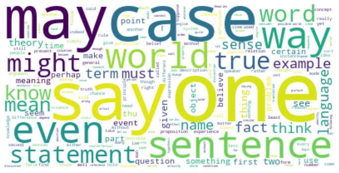

```python
analytic2['filtered_txt'] = analytic2['tokenized_txt'].apply(lambda x:[item for item in x.replace("'","").replace('[',"").replace(']',"").replace(" ","").split(',') if item not in stopwords])
a2_words = analytic2['filtered_txt'].sum()

wordcloud = WordCloud(background_color="white").generate(' '.join(a2_words))
plt.figure(figsize = (12, 12))
plt.imshow(wordcloud)

plt.axis("off")
plt.show()
```

We can see very similar, if not the same, words are being used across the two eras. Words like "one," "case," "fact," "true." One notable difference is there seems to be more usage of "sentence," "language," and "term" in the second era, indicating more focus on the details of the structure of language. Overall, however, the commonly-used words are remarkably similar for texts written over 30 years apart.

Next, we can consider any differences in structure across the two analytic eras, mainly differences in the length of sentences.

```python
print("Average sentence length of first era: " + str(analytic1['sentence_length'].mean()))
print("Average sentence length of second era: " + str(analytic2['sentence_length'].mean()))
```

```
Average sentence length of first era: 148.406008238722
Average sentence length of second era: 112.59427779732583
```

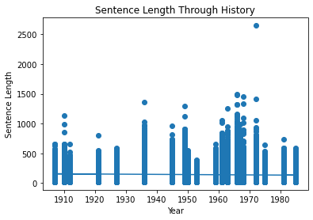

```python
import numpy as np

post1900 = df[df['original_publication_date'] > 1900]
x = np.array(post1900['original_publication_date'])
y = np.array(post1900['sentence_length'])

a, b = np.polyfit(x, y, 1)

plt.scatter(x, y)
plt.plot(x, a*x+b)
plt.title('Sentence Length Through History')
plt.xlabel('Year')
plt.ylabel('Sentence Length')
```

Because of this generally slow decreasing trend across schools, it is difficult to conclude that this difference is evidence of two very different eras of the analytic school of philosophy.

Finally, we consider how the two eras might differ in emotion of text. Using an NRC lexicon for emotion classification, we can determine the top emotions of each sentence in the two eras and the score associated with it. We can then sum these scores across emotion category for each era, and normalize by the number of sentences in the era. The resulting weights give a sense of which emotions dominated the text of each analytic era on average. The results are shown in the bar graph below.

```python
pip install NRCLex==3.0.0
```

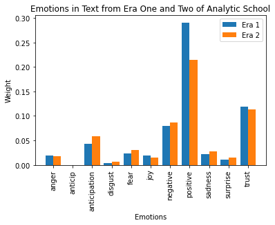

```python
from nrclex import NRCLex

def get_top_emot(row):
    sent = NRCLex(row['sentence_str'])
    return sent.top_emotions

analytic1['top_emotions'] = analytic1.apply(lambda row: get_top_emot(row),axis = 1)
analytic2['top_emotions'] = analytic2.apply(lambda row: get_top_emot(row),axis = 1)

a1_emotions = analytic1['top_emotions'].sum()

emotions = {}
for emotion, value in a1_emotions:
    if emotion not in emotions:
        emotions[emotion] = value
    else:
        emotions[emotion] += value

for key,value in emotions.items():
    emotions[key] = value / analytic1.shape[0]

emotions1 = dict(sorted(emotions.items()))

a2_emotions = analytic2['top_emotions'].sum()

emotions = {}
for emotion, value in a2_emotions:
    if emotion not in emotions:
        emotions[emotion] = value
    else:
        emotions[emotion] += value

for key,value in emotions.items():
    emotions[key] = value / analytic2.shape[0]

emotions2 = dict(sorted(emotions.items()))

X = list(emotions1.keys())
Y1 = emotions1.values()
Y2 = emotions2.values()

X_axis = np.arange(len(X))

plt.bar(X_axis - 0.2, Y1, 0.4, label = 'Era 1')
plt.bar(X_axis + 0.2, Y2, 0.4, label = 'Era 2')

plt.xticks(X_axis, X)
plt.xlabel("Emotions")
plt.ylabel("Weight")
plt.title("Emotions in Text from Era One and Two of Analytic School")
plt.legend()
plt.xticks(rotation='vertical')
plt.show()
```

Again, we see a similar distribution of emotions across these eras. While the second era saw a significantly lower weight for positivity, all other emotions saw very minor fluctuations.

While minor differences can be found between these two eras of the analytic school of philosophy in terms of their ideas, structure, and emotion, they are remarkably similar given the over 30-year gap between them. This is a testament to the analytic school's consistency and persistence through the history of philosophy. This finding led me to consider how significantly the continental school, the school that followed and overtook the analytic school, was able to deviate from its predecessor. Would the analytic school's remarkable consistency over nearly a century make it difficult for the continental school to change ideas, structure, and emotion dramatically? We can perform the same three analyses, comparing the analytic and continental schools to see.

The word clouds of most commonly-used words for the analytic and continental schools are below.

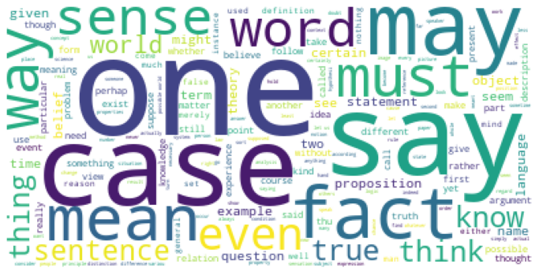

```python
analytic['filtered_txt'] = analytic['tokenized_txt'].apply(lambda x:[item for item in x.replace("'","").replace('[',"").replace(']',"").replace(" ","").split(',') if item not in stopwords])
a_words = analytic['filtered_txt'].sum()

wordcloud = WordCloud(background_color="white").generate(' '.join(a_words))
plt.figure(figsize = (12, 12))
plt.imshow(wordcloud)

plt.axis("off")
plt.show()
```

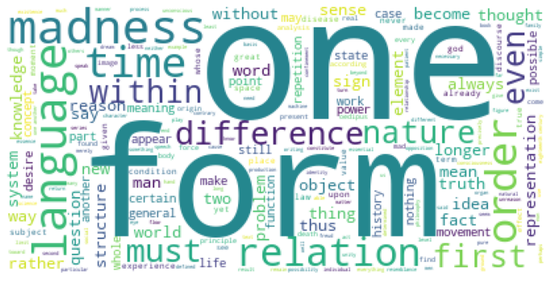

```python
con = df[df['school'] == 'continental']
con['filtered_txt'] = con['tokenized_txt'].apply(lambda x:[item for item in x.replace("'","").replace('[',"").replace(']',"").replace(" ","").split(',') if item not in stopwords])
con_words = con['filtered_txt'].sum()

wordcloud = WordCloud(background_color="white").generate(' '.join(con_words))
plt.figure(figsize = (12, 12))
plt.imshow(wordcloud)

plt.axis("off")
plt.show()
```

While some words remain, there are much more significant differences seen in these two word bubbles. For example, the addition of words like "form," "madness," "difference," "time," etc. This indicates a significant shift in ideas dicussed by the two schools.

Next, we look at sentence length difference across the two schools.

```python
print("Average sentence length of analytic school: " + str(analytic['sentence_length'].mean()))
print("Average sentence length of continential school: " + str(con['sentence_length'].mean()))
```

```
Average sentence length of analytic school: 119.02520523229589
Average sentence length of continential school: 171.79206015571805
```

Finally, the emotion analysis. The bar graph below shows the difference in emotion weights for sentences of the continental and analytic schools.

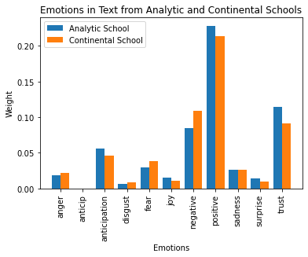

```python
analytic['top_emotions'] = analytic.apply(lambda row: get_top_emot(row),axis = 1)
con['top_emotions'] = con.apply(lambda row: get_top_emot(row),axis = 1)

a_emotions = analytic['top_emotions'].sum()

emotions = {}
for emotion, value in a_emotions:
    if emotion not in emotions:
        emotions[emotion] = value
    else:
        emotions[emotion] += value

for key,value in emotions.items():
    emotions[key] = value / analytic.shape[0]

emotions1 = dict(sorted(emotions.items()))

con_emotions = con['top_emotions'].sum()

emotions = {}
for emotion, value in con_emotions:
    if emotion not in emotions:
        emotions[emotion] = value
    else:
        emotions[emotion] += value

for key,value in emotions.items():
    emotions[key] = value / con.shape[0]

emotions2 = dict(sorted(emotions.items()))

X = list(emotions1.keys())
Y1 = emotions1.values()
Y2 = emotions2.values()

X_axis = np.arange(len(X))

plt.bar(X_axis - 0.2, Y1, 0.4, label = 'Analytic School')
plt.bar(X_axis + 0.2, Y2, 0.4, label = 'Continental School')

plt.xticks(X_axis, X)
plt.xlabel("Emotions")
plt.ylabel("Weight")
plt.title("Emotions in Text from Analytic and Continental Schools")
plt.legend()
plt.xticks(rotation='vertical')
plt.show()
```

Here, we see differences similar or even smaller in magnitude compared to those seen when comparing the two eras of the analytic school. Perhaps the analytic school's consistency and persistence in emotion over many years made it difficult for the following school, the continental school, to deviate much in emotion.

In conclusion, it seems that the analytic school's consistency through its two eras did not hinder the continental school's ability to deviate from its predecessor in ideas and structure, but perhaps in emotion. Going forward, it may be interesting to study this same question on a more continuous, rather than discrete scale. Specifically, it may be interesting to look at the continental school's ideas, structure, and emotions as a function of time to assess if the continental school saw a gradual shift away from the ideas, structure, and emotions more similar to the analytic school or an abrupt rejection of its predecessor.